Saltar al contenido principal

# Mercado de arriendos en Bogotá, Medellín y Cali

Taller 10: medidas estadísticas y comunicación de resultados

Este informe usa 900 arriendos de los datos originales, con errores. Las cifras del texto se calculan directamente desde los datos: si se corrigen los errores (parámetro `corregir_errores: true`, que deja fuera los registros con un cero de más) y se vuelve a renderizar, todas cambian solas.

## 1. ¿Cuánto cuesta un arriendo típico?

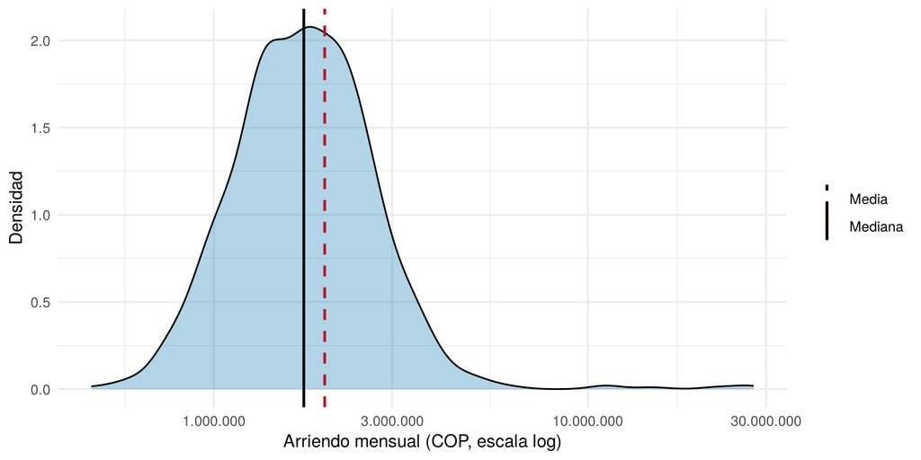

Figura 1: Densidad del arriendo mensual (escala logarítmica) con la media y la mediana.

La media es de $1.978.789 y la mediana de $1.740.000; la asimetría es 10,12. Como la distribución está sesgada a la derecha, el arriendo típico se reporta con la mediana: $1.740.000. La media queda 14 % por encima de la mediana porque unos pocos valores muy altos la arrastran.

## 2. ¿En qué ciudad los precios son más dispersos?

Tabla 1: Arriendo mensual por ciudad (COP)

| Ciudad | n | Media | Mediana | DE | CV | IQR | IQR/mediana |
| --- | --- | --- | --- | --- | --- | --- | --- |
| Bogotá | 470 | 1.986.191 | 1.760.000 | 1.481.285 | 74,6 % | 967.500 | 55,0 % |
| Cali | 184 | 1.910.543 | 1.615.000 | 1.799.999 | 94,2 % | 962.500 | 59,6 % |
| Medellín | 246 | 2.015.691 | 1.740.000 | 1.919.465 | 95,2 % | 962.500 | 55,3 % |

Según el coeficiente de variación, la ciudad más dispersa es Medellín (CV de 95 %) y la menos dispersa Bogotá (75 %). Con una medida robusta, el IQR relativo a la mediana, las tres ciudades quedan entre 55 % y 60 %. La diferencia que muestra el CV no se confirma con el IQR: el CV depende de la media y la desviación estándar, que son sensibles a los valores extremos, así que la mayor dispersión aparente se debe a unos pocos registros. En todos los casos el CV supera el 30 %, así que los precios dentro de cada ciudad son heterogéneos (varían mucho con el estrato y el área).

## 3. ¿Qué registros son sospechosos?

Tabla 2: Arriendos atípicos según la regla del IQR

| Registro | Ciudad | Estrato | Área (m²) | Arriendo | Esperado | Veces el esperado | Diagnóstico |
| --- | --- | --- | --- | --- | --- | --- | --- |
| 624 | Medellín | 2 | 99 | 27.800.000 | 1.828.056 | 15,2 | Error de digitación |
| 201 | Bogotá | 4 | 75 | 25.800.000 | 2.091.641 | 12,3 | Error de digitación |
| 617 | Cali | 5 | 58 | 22.000.000 | 1.967.239 | 11,2 | Error de digitación |
| 563 | Bogotá | 3 | 41 | 14.900.000 | 1.340.577 | 11,1 | Error de digitación |
| 652 | Cali | 2 | 68 | 11.500.000 | 1.373.148 | 8,4 | Error de digitación |
| 486 | Medellín | 4 | 50 | 10.900.000 | 1.746.215 | 6,2 | Error de digitación |
| 65 | Bogotá | 4 | 111 | 4.870.000 | 2.539.340 | 1,9 | Arriendo alto legítimo |
| 272 | Medellín | 6 | 82 | 5.080.000 | 2.987.205 | 1,7 | Arriendo alto legítimo |
| 410 | Bogotá | 5 | 81 | 4.020.000 | 2.514.558 | 1,6 | Arriendo alto legítimo |
| 1 | Medellín | 6 | 152 | 6.320.000 | 4.053.849 | 1,6 | Arriendo alto legítimo |
| 376 | Medellín | 5 | 108 | 4.510.000 | 2.958.019 | 1,5 | Arriendo alto legítimo |
| 74 | Bogotá | 5 | 86 | 3.930.000 | 2.590.188 | 1,5 | Arriendo alto legítimo |
| 876 | Bogotá | 6 | 97 | 4.780.000 | 3.181.496 | 1,5 | Arriendo alto legítimo |
| 869 | Bogotá | 6 | 136 | 5.440.000 | 3.760.465 | 1,4 | Arriendo alto legítimo |
| 292 | Bogotá | 6 | 110 | 4.680.000 | 3.385.743 | 1,4 | Arriendo alto legítimo |
| 114 | Bogotá | 5 | 114 | 3.990.000 | 2.977.759 | 1,3 | Arriendo alto legítimo |
| 181 | Bogotá | 5 | 107 | 3.810.000 | 2.885.852 | 1,3 | Arriendo alto legítimo |
| 498 | Bogotá | 5 | 112 | 3.850.000 | 2.951.798 | 1,3 | Arriendo alto legítimo |
| 193 | Bogotá | 6 | 178 | 5.560.000 | 4.296.019 | 1,3 | Arriendo alto legítimo |
| 821 | Medellín | 6 | 92 | 4.030.000 | 3.162.195 | 1,3 | Arriendo alto legítimo |
| 716 | Bogotá | 6 | 116 | 4.290.000 | 3.475.882 | 1,2 | Arriendo alto legítimo |
| 612 | Cali | 6 | 118 | 3.990.000 | 3.235.173 | 1,2 | Arriendo alto legítimo |
| 884 | Medellín | 6 | 99 | 3.990.000 | 3.279.024 | 1,2 | Arriendo alto legítimo |
| 497 | Medellín | 6 | 128 | 4.070.000 | 3.723.437 | 1,1 | Arriendo alto legítimo |
| 715 | Bogotá | 5 | 207 | 4.270.000 | 3.999.974 | 1,1 | Arriendo alto legítimo |
| 514 | Medellín | 6 | 268 | 4.780.000 | 5.366.799 | 0,9 | Arriendo alto legítimo |

## 4. ¿Qué variables se asocian con el arriendo?

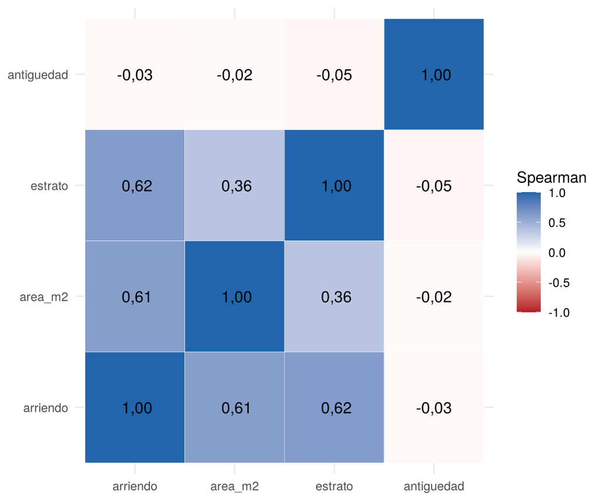

Figura 2: Correlograma de Spearman.

El arriendo se asocia sobre todo con el área (Spearman 0,61, Pearson 0,29) y con el estrato (Spearman 0,62; se usa Spearman porque el estrato es ordinal). La antigüedad casi no se relaciona con el precio (-0,03). La diferencia entre Pearson y Spearman en el área se debe a los valores extremos: Pearson usa los valores y se deja arrastrar por ellos, Spearman usa rangos.

## 5. ¿Qué cambia al depurar?

Tabla 3: Medidas con y sin los 6 errores de digitación

| Medida | Con errores | Sin los errores | ¿Cambió mucho? |
| --- | --- | --- | --- |
| Media | 1.978.789 | 1.865.783 | Sí |
| Mediana | 1.740.000 | 1.740.000 | No |
| Asimetría | 10,12 | 1,27 | Sí |
| CV por ciudad | 75 % a 95 % | 41 % a 42 % | Sí |
| Pearson con el área | 0,29 | 0,63 | Sí |
| Spearman con el área | 0,61 | 0,62 | No |

Al quitar los 6 registros con error de digitación, la media pasa de $1.978.789 a $1.865.783, la asimetría de 10,12 a 1,27 y la correlación de Pearson con el área de 0,29 a 0,63. La mediana (1.740.000 y 1.740.000) y la correlación de Spearman (0,61 y 0,62) prácticamente no se mueven.

**Pregunta de cierre.** Las medidas basadas en el orden de los datos (mediana, IQR, Spearman) son robustas: 6 valores entre 900 no cambian qué registro queda en el centro ni el rango de cada observación. Las basadas en momentos (media, desviación estándar, CV, asimetría, Pearson) no lo son, porque usan la magnitud de cada valor: un arriendo diez veces más alto pesa mucho en la suma, y todavía más cuando las desviaciones se elevan al cuadrado o al cubo.